# Lab04

Luqing Ren

9/9/2020

# step 1:load the data

```r
download.file("https://raw.githubusercontent.com/USCbiostats/data-science-data/master/02_met/met_all.gz",
              "met_all.gz", method = "libcurl", timeout = 60)
library(data.table)
met <- fread("met_all.gz")
```

# step 2: prepare the data

-Remove temperatures less than -17C -Make sure there are no missing data in the key variables coded as 9999, 999, etc -Take monthly averages by weather station -Create a region variable for NW, SW, NE, SE based on lon = -98.00 and lat = 39.71 -degrees Create a categorical variable for elevation as in the lecture slides

```r
library(tidyverse)
met <- met[met$temp >-17]
met[met$elev==9999.0] <- NA

met_avg <- met[,.(temp = mean(temp, na.rm = T), rh = mean(rh, na.rm = T),
wind.sp = mean(wind.sp, na.rm = T), vis.dist = mean(vis.dist, na.rm = T),
dew.point = mean(dew.point, na.rm = T), lat = mean(lat), lon = mean(lon),
ele = mean(elev, na.rm = T)) , by = "USAFID"]

met_avg$region <- ifelse(met_avg$lon > -98 & met_avg$lat > 39.71, "north east",
                    ifelse(met_avg$lon > -98 & met_avg$lat < 39.71, "south east",
                      ifelse(met_avg$lon < -98 & met_avg$lat > 39.71,"north west","south west")))
table(met_avg$region)
```

```
##
## north east north west south east south west
##        487        147        656        298
```

```r
met_avg$elev_cat <- if_else(met_avg$ele>252, "high","low")
table(met_avg$elev_cat)
```

```
##
## high  low
##  756  832
```

```r
dim(met_avg)
```

```
## [1] 1589   11
```

```r
names(met_avg)
```

```
##  [1] "USAFID"    "temp"      "rh"        "wind.sp"   "vis.dist"  "dew.point"
##  [7] "lat"       "lon"       "ele"       "region"    "elev_cat"
```

# step 3: Use geom_boxplot to examine the dew point temperature and relative humidity by region

-Use facets -Make sure to deal with NA category -Describe what you observe in the graph

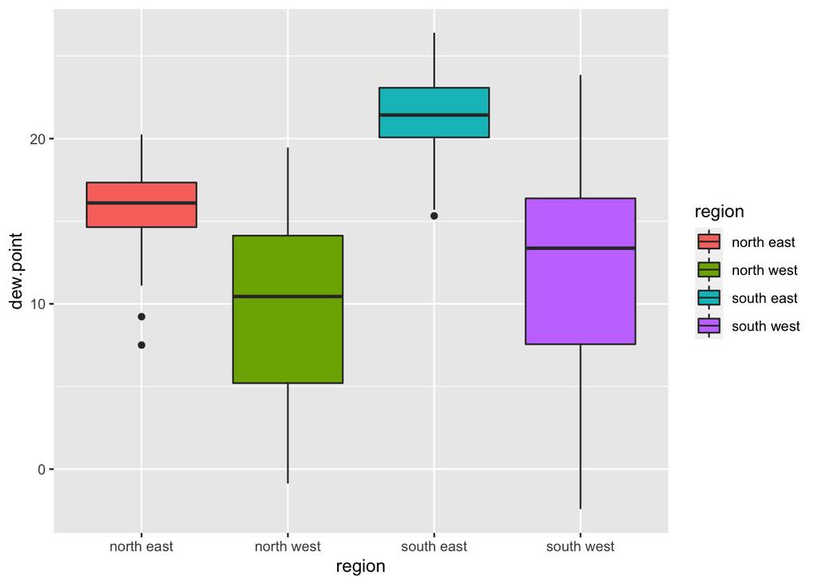

```r
met_avg %>%
  filter(!(region %in% NA)) %>%
ggplot()+
  geom_boxplot(mapping = aes( y = dew.point, x= region, fill= region))
```

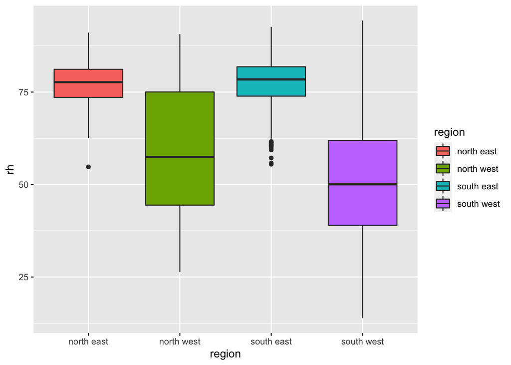

```r
met_avg %>%
  filter(!(region %in% NA)) %>%
ggplot()+
  geom_boxplot(mapping = aes( y = rh, x= region, fill= region))
```

-South east has the highest dew point temperature because relative humidity makes the weather warmer. On the other hand, north west has lower dew point temperature. North east and south west are in the middle dew point temperature. -South west has the lowest relative humidity makes the weather there dryer and colder. North east and south east have higher relative humidity, and the weather is warmer.

# step 4: Use geom_point with stat_smooth to examine the association between dew point temperature and relative humidity by region

-Color points by region -Make sure to deal with NA category -Fit a linear regression line by region Describe what you observe in the graph -Describe what you observe in the graph

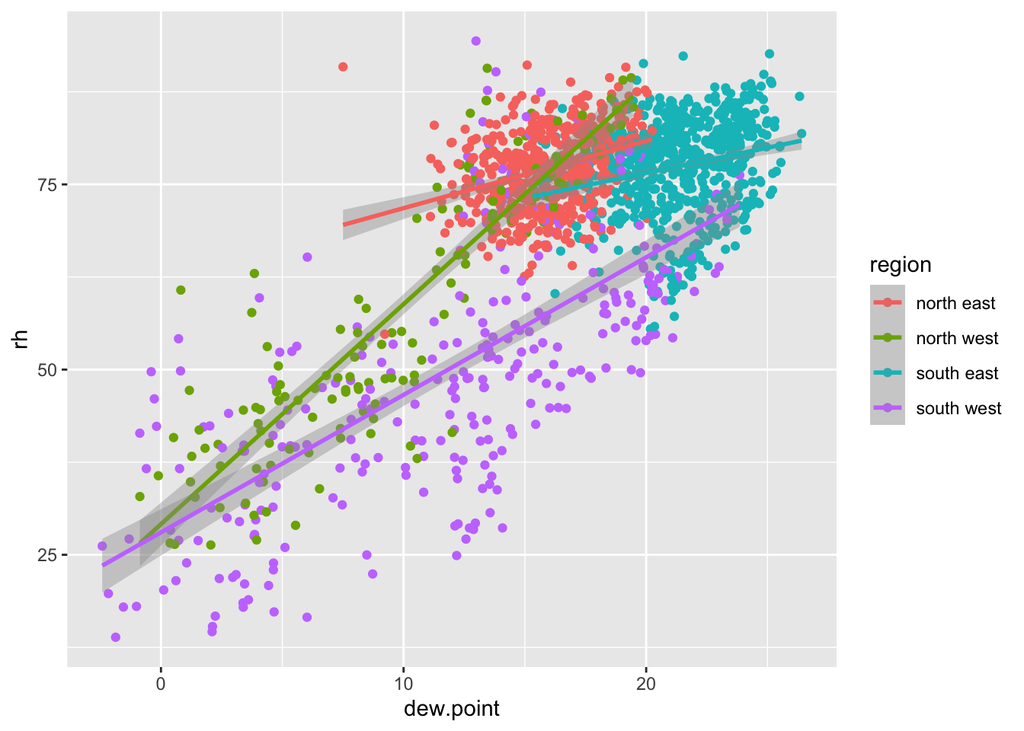

```r
met_avg %>%
  filter (!(region %in% NA)) %>%
     ggplot(mapping = aes(x= dew.point, y=rh, color= region))+  # association by region
     geom_point()+
     stat_smooth(method =lm)
```

-The association between dew point temperature and relative humidity is positive in all regions. -Regional observations: north east and south east have relative higher humidity. The regression lines in these two regions are much flatter, which suggest that increase dew point temperature has a slight increase at humidity. On the other hand, The lines of north west and south west are much steeper than east region, which suggest that increase dew point temperature has a higher increase at humidity.

#step 5: Use geom_bar to create barplots of the weather stations by elevation category coloured by region -Bars by elevation category -Change colors from the default. Color by region using scale_fill_brewer see this create nice -labels on axes and add a title -Describe what you observe in the graph

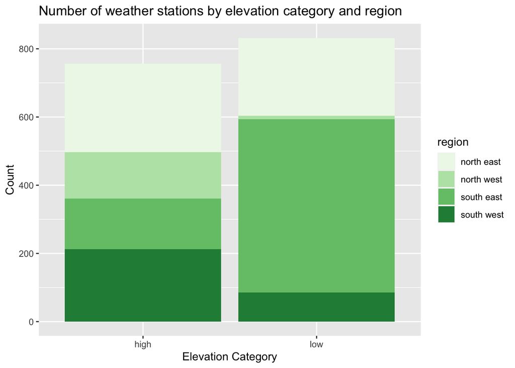

```r
met_avg %>%
  filter(!(region %in% NA)) %>%
    ggplot()+
    geom_bar(mapping = aes(x = elev_cat, fill = region))+
    scale_fill_brewer(palette = "red")+
    labs(title = "Number of weather stations by elevation category and region", x = "Elevation Category", y ="Count")+
     theme_gray()
```

#step 6: Use stat_summary to examine mean dew point and relative humidity by region with standard deviation error bars -Make sure to remove NA -Use fun.data=“mean_sdl” in stat_summary -Describe the graph and what you observe

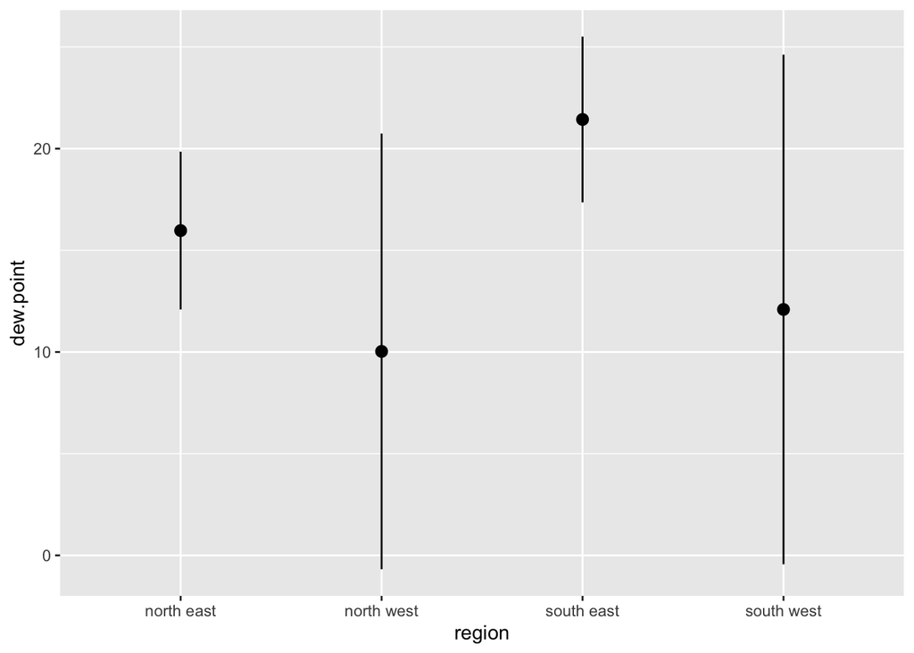

```r
met_avg %>%
 filter(!(region %in% NA)) %>%
  ggplot(mapping= aes(x= region, y= dew.point))+
  stat_summary(fun.data = "mean_sdl")
```

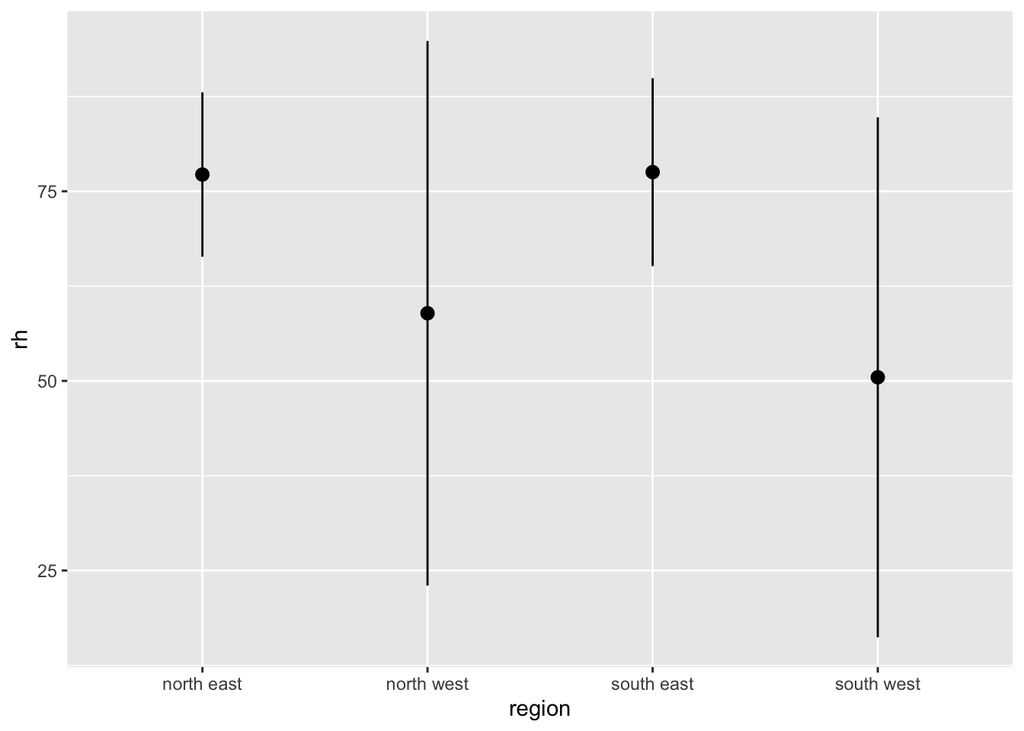

```r
met_avg %>%
 filter(!(region %in% NA)) %>%
  ggplot(mapping= aes(x= region, y= rh))+
  stat_summary(fun.data = "mean_sdl")
```

-South east has the highest mean of dew point temperature, and north west has the lowest mean of dew point temperature. The north west and south west have larger standard  
deviation range, and north east and south east have smaller range of standard deviation. -South east and north east have similar mean of relative humidity, and north west and south west have lower mean of relative humidity.The north west and south west have larger standard deviation range, and north east and south east have smaller range of standard deviation.

#step 7: Make a map showing the spatial trend in relative humidity in the US -Make sure to remove NA -Use leaflet() -Make a color palette with custom colors Add a legend

```r
library(leaflet)
met_avg2<- met_avg[!is.na(rh)]
rh_pal = colorNumeric(c('blue','purple','red'), domain = met_avg2$rh)
leaflet(met_avg2) %>%
addProviderTiles('OpenStreetMap') %>%
  addCircles(lat=~lat,lng=~lon, color=~rh_pal(rh),opacity=1, fillOpacity=1,radius=500) %>%
  addLegend('bottomleft', pal = rh_pal, values = met_avg$rh, title ="Relative Humidity",opacity = 1)
```

[interactive chart not shown]

-North west and south west region have a lower humidity across the US, and north east and south east regions have relatively higher humidity.

# step 8: Use a ggplot extension

# Use geom_boxplot to estimate Dew point temperature by region and lets it transition between the elevation category.

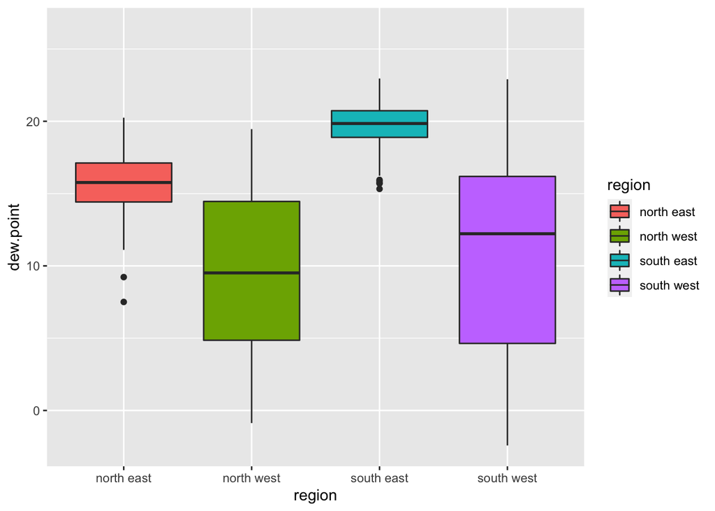

```r
library(gganimate)
library(gifski)
met_avg %>%
  filter(!(region %in% NA)) %>%
  ggplot()+
  geom_boxplot(mapping = aes( y = dew.point, x= region, fill= region))+
  transition_states(
    elev_cat,
    transition_length = 2,
    state_length = 1) +
  enter_fade() +
  exit_shrink() +
  ease_aes('sine-in-out')
```